# Meteorite Landings

## Meteorite Landing Analysis

This project analyzes data regarding mass, location, and composition of meteorite landings using a dataset titled "Meteorite_Landing.csv". The dataset used in this project was sourced from kaggle.com.

```python
import pandas as pd
import matplotlib.pyplot as plt
import seaborn as sns
import numpy as np
%matplotlib inline
import warnings

warnings.filterwarnings("ignore", category=FutureWarning)
```

```python
df = pd.read_csv('Meteorite_Landings.csv')
df.head()
```

|  | name | id | nametype | recclass | mass (g) | fall | year | reclat | reclong | GeoLocation | Unnamed: 10 |
| --- | --- | --- | --- | --- | --- | --- | --- | --- | --- | --- | --- |
| 0 | Aachen | 1 | Valid | L5 | 21.0 | Fell | 1880.0 | 50.77500 | 6.08333 | (50.775, 6.08333) | NaN |
| 1 | Aarhus | 2 | Valid | H6 | 720.0 | Fell | 1951.0 | 56.18333 | 10.23333 | (56.18333, 10.23333) | NaN |
| 2 | Abee | 6 | Valid | EH4 | 107000.0 | Fell | 1952.0 | 54.21667 | -113.00000 | (54.21667, -113.0) | NaN |
| 3 | Acapulco | 10 | Valid | Acapulcoite | 1914.0 | Fell | 1976.0 | 16.88333 | -99.90000 | (16.88333, -99.9) | NaN |
| 4 | Achiras | 370 | Valid | L6 | 780.0 | Fell | 1902.0 | -33.16667 | -64.95000 | (-33.16667, -64.95) | NaN |

```python
df.drop(columns=["Unnamed: 10"], inplace=True)
df.columns
```

```
Index(['name', 'id', 'nametype', 'recclass', 'mass (g)', 'fall', 'year',
       'reclat', 'reclong', 'GeoLocation'],
      dtype='object')
```

```python
df.shape
```

```
(45716, 10)
```

```python
df.info()
```

```
<class 'pandas.core.frame.DataFrame'>
RangeIndex: 45716 entries, 0 to 45715
Data columns (total 10 columns):
 #   Column       Non-Null Count  Dtype
---  ------       --------------  -----
 0   name         45716 non-null  object
 1   id           45716 non-null  int64
 2   nametype     45716 non-null  object
 3   recclass     45716 non-null  object
 4   mass (g)     45585 non-null  float64
 5   fall         45716 non-null  object
 6   year         45425 non-null  float64
 7   reclat       38401 non-null  float64
 8   reclong      38401 non-null  float64
 9   GeoLocation  38401 non-null  object
dtypes: float64(4), int64(1), object(5)
memory usage: 3.5+ MB
```

```python
df.describe()
```

|  | id | mass (g) | year | reclat | reclong |
| --- | --- | --- | --- | --- | --- |
| count | 45716.000000 | 4.558500e+04 | 45425.000000 | 38401.000000 | 38401.000000 |
| mean | 26889.735104 | 1.327808e+04 | 1991.828817 | -39.122580 | 61.074319 |
| std | 16860.683030 | 5.749889e+05 | 25.052766 | 46.378511 | 80.647298 |
| min | 1.000000 | 0.000000e+00 | 860.000000 | -87.366670 | -165.433330 |
| 25% | 12688.750000 | 7.200000e+00 | 1987.000000 | -76.714240 | 0.000000 |
| 50% | 24261.500000 | 3.260000e+01 | 1998.000000 | -71.500000 | 35.666670 |
| 75% | 40656.750000 | 2.026000e+02 | 2003.000000 | 0.000000 | 157.166670 |
| max | 57458.000000 | 6.000000e+07 | 2101.000000 | 81.166670 | 354.473330 |

```python
df.isna().sum()
```

```
name              0
id                0
nametype          0
recclass          0
mass (g)        131
fall              0
year            291
reclat         7315
reclong        7315
GeoLocation    7315
dtype: int64
```

```python
print("Total rows:", len(df))
print("Rows with location:", df.dropna(subset=["reclat", "reclong", "GeoLocation"]).shape[0])
```

```
Total rows: 45716
Rows with location: 38401
```

```python
# Drop rows where either reclat or reclong is missing
df = df.dropna(subset=["reclat", "reclong", 'GeoLocation'])
```

```python
print("Before:", len(df))
print("After dropping null mass/year:", df.dropna(subset=["mass (g)", "year"]).shape[0])
```

```
Before: 38401
After dropping null mass/year: 38115
```

```python
df_raw = df
df_raw.head()
```

|  | name | id | nametype | recclass | mass (g) | fall | year | reclat | reclong | GeoLocation |
| --- | --- | --- | --- | --- | --- | --- | --- | --- | --- | --- |
| 0 | Aachen | 1 | Valid | L5 | 21.0 | Fell | 1880.0 | 50.77500 | 6.08333 | (50.775, 6.08333) |
| 1 | Aarhus | 2 | Valid | H6 | 720.0 | Fell | 1951.0 | 56.18333 | 10.23333 | (56.18333, 10.23333) |
| 2 | Abee | 6 | Valid | EH4 | 107000.0 | Fell | 1952.0 | 54.21667 | -113.00000 | (54.21667, -113.0) |
| 3 | Acapulco | 10 | Valid | Acapulcoite | 1914.0 | Fell | 1976.0 | 16.88333 | -99.90000 | (16.88333, -99.9) |
| 4 | Achiras | 370 | Valid | L6 | 780.0 | Fell | 1902.0 | -33.16667 | -64.95000 | (-33.16667, -64.95) |

```python
df_raw.info()
```

```
<class 'pandas.core.frame.DataFrame'>
Index: 38401 entries, 0 to 45715
Data columns (total 10 columns):
 #   Column       Non-Null Count  Dtype
---  ------       --------------  -----
 0   name         38401 non-null  object
 1   id           38401 non-null  int64
 2   nametype     38401 non-null  object
 3   recclass     38401 non-null  object
 4   mass (g)     38282 non-null  float64
 5   fall         38401 non-null  object
 6   year         38223 non-null  float64
 7   reclat       38401 non-null  float64
 8   reclong      38401 non-null  float64
 9   GeoLocation  38401 non-null  object
dtypes: float64(4), int64(1), object(5)
memory usage: 3.2+ MB
```

```python
# Drop rows where either mass or year is missing
df = df.dropna(subset=["mass (g)", "year"])
```

```python
df.info()
```

```
<class 'pandas.core.frame.DataFrame'>
Index: 38115 entries, 0 to 45715
Data columns (total 10 columns):
 #   Column       Non-Null Count  Dtype
---  ------       --------------  -----
 0   name         38115 non-null  object
 1   id           38115 non-null  int64
 2   nametype     38115 non-null  object
 3   recclass     38115 non-null  object
 4   mass (g)     38115 non-null  float64
 5   fall         38115 non-null  object
 6   year         38115 non-null  float64
 7   reclat       38115 non-null  float64
 8   reclong      38115 non-null  float64
 9   GeoLocation  38115 non-null  object
dtypes: float64(4), int64(1), object(5)
memory usage: 3.2+ MB
```

```python
df["year"] = df["year"].astype("int")
```

```python
df.info()
```

```
<class 'pandas.core.frame.DataFrame'>
Index: 38115 entries, 0 to 45715
Data columns (total 10 columns):
 #   Column       Non-Null Count  Dtype
---  ------       --------------  -----
 0   name         38115 non-null  object
 1   id           38115 non-null  int64
 2   nametype     38115 non-null  object
 3   recclass     38115 non-null  object
 4   mass (g)     38115 non-null  float64
 5   fall         38115 non-null  object
 6   year         38115 non-null  int32
 7   reclat       38115 non-null  float64
 8   reclong      38115 non-null  float64
 9   GeoLocation  38115 non-null  object
dtypes: float64(3), int32(1), int64(1), object(5)
memory usage: 3.1+ MB
```

```python
df['nametype'].value_counts()
```

```
nametype
Valid     38094
Relict       21
Name: count, dtype: int64
```

```python
df['fall'].value_counts()
```

```
fall
Found    37050
Fell      1065
Name: count, dtype: int64
```

```python
print("Smallest mass:", df["mass (g)"].min())
print("Largest mass:", df["mass (g)"].max())
```

```
Smallest mass: 0.0
Largest mass: 60000000.0
```

```python
df[df['mass (g)'] == 0].shape
```

```
(19, 10)
```

```python
df[df['mass (g)'] == 0].head()
```

|  | name | id | nametype | recclass | mass (g) | fall | year | reclat | reclong | GeoLocation |
| --- | --- | --- | --- | --- | --- | --- | --- | --- | --- | --- |
| 12640 | Gove | 52859 | Relict | Relict iron | 0.0 | Found | 1979 | -12.26333 | 136.83833 | (-12.26333, 136.83833) |
| 25557 | Miller Range 090478 | 55953 | Valid | CO3 | 0.0 | Found | 2009 | 0.00000 | 0.00000 | (0.0, 0.0) |
| 31061 | Österplana 048 | 56147 | Relict | Relict OC | 0.0 | Found | 2004 | 58.58333 | 13.43333 | (58.58333, 13.43333) |
| 31062 | Österplana 049 | 56148 | Relict | Relict OC | 0.0 | Found | 2012 | 58.58333 | 13.43333 | (58.58333, 13.43333) |
| 31063 | Österplana 050 | 56149 | Relict | Relict OC | 0.0 | Found | 2003 | 58.58333 | 13.43333 | (58.58333, 13.43333) |

```python
df = df[df["mass (g)"] > 0]
df[df['mass (g)'] == 0].head()
```

|  | name | id | nametype | recclass | mass (g) | fall | year | reclat | reclong | GeoLocation |
| --- | --- | --- | --- | --- | --- | --- | --- | --- | --- | --- |

```python
df[df["mass (g)"] == df["mass (g)"].max()]
```

|  | name | id | nametype | recclass | mass (g) | fall | year | reclat | reclong | GeoLocation |
| --- | --- | --- | --- | --- | --- | --- | --- | --- | --- | --- |
| 16392 | Hoba | 11890 | Valid | Iron, IVB | 60000000.0 | Found | 1920 | -19.58333 | 17.91667 | (-19.58333, 17.91667) |

```python
print("Earliest year:", df["year"].min())
print("Most recent year:", df["year"].max())
```

```
Earliest year: 860
Most recent year: 2101
```

```python
import datetime

current_year = datetime.datetime.now().year

future_rows = df[df["year"] > current_year]

future_rows
```

|  | name | id | nametype | recclass | mass (g) | fall | year | reclat | reclong | GeoLocation |
| --- | --- | --- | --- | --- | --- | --- | --- | --- | --- | --- |
| 30682 | Northwest Africa 7701 | 57150 | Valid | CK6 | 55.0 | Found | 2101 | 0.0 | 0.0 | (0.0, 0.0) |

```python
zero_geo_rows = df[df["GeoLocation"] == '(0.0, 0.0)']

zero_geo_rows
```

|  | name | id | nametype | recclass | mass (g) | fall | year | reclat | reclong | GeoLocation |
| --- | --- | --- | --- | --- | --- | --- | --- | --- | --- | --- |
| 597 | Mason Gully | 53653 | Valid | H5 | 24.54 | Fell | 2010 | 0.0 | 0.0 | (0.0, 0.0) |
| 1655 | Allan Hills 09004 | 52119 | Valid | Howardite | 221.70 | Found | 2009 | 0.0 | 0.0 | (0.0, 0.0) |
| 1656 | Allan Hills 09005 | 55797 | Valid | L5 | 122.30 | Found | 2009 | 0.0 | 0.0 | (0.0, 0.0) |
| 1657 | Allan Hills 09006 | 55798 | Valid | H5 | 104.30 | Found | 2009 | 0.0 | 0.0 | (0.0, 0.0) |
| 1658 | Allan Hills 09008 | 55799 | Valid | H5 | 31.30 | Found | 2009 | 0.0 | 0.0 | (0.0, 0.0) |
| ... | ... | ... | ... | ... | ... | ... | ... | ... | ... | ... |
| 45655 | Yamato 984144 | 40764 | Valid | H6 | 37.44 | Found | 1998 | 0.0 | 0.0 | (0.0, 0.0) |
| 45656 | Yamato 984145 | 40765 | Valid | L6 | 54.80 | Found | 1998 | 0.0 | 0.0 | (0.0, 0.0) |
| 45657 | Yamato 984146 | 40766 | Valid | H3 | 19.32 | Found | 1998 | 0.0 | 0.0 | (0.0, 0.0) |
| 45658 | Yamato 984147 | 40767 | Valid | LL6 | 118.90 | Found | 1998 | 0.0 | 0.0 | (0.0, 0.0) |
| 45659 | Yamato 984148 | 40768 | Valid | L5 | 4.59 | Found | 1998 | 0.0 | 0.0 | (0.0, 0.0) |

6185 rows × 10 columns

```python
df = df[df["GeoLocation"] != '(0.0, 0.0)']
zero_geo_rows = df[df["GeoLocation"] == '(0.0, 0.0)']

zero_geo_rows
```

|  | name | id | nametype | recclass | mass (g) | fall | year | reclat | reclong | GeoLocation |
| --- | --- | --- | --- | --- | --- | --- | --- | --- | --- | --- |

```python
df.info()
```

```
<class 'pandas.core.frame.DataFrame'>
Index: 31911 entries, 0 to 45715
Data columns (total 10 columns):
 #   Column       Non-Null Count  Dtype
---  ------       --------------  -----
 0   name         31911 non-null  object
 1   id           31911 non-null  int64
 2   nametype     31911 non-null  object
 3   recclass     31911 non-null  object
 4   mass (g)     31911 non-null  float64
 5   fall         31911 non-null  object
 6   year         31911 non-null  int32
 7   reclat       31911 non-null  float64
 8   reclong      31911 non-null  float64
 9   GeoLocation  31911 non-null  object
dtypes: float64(3), int32(1), int64(1), object(5)
memory usage: 2.6+ MB
```

```python
print("Most recent year:", df["year"].max())
```

```
Most recent year: 2013
```

```python
df['century'] = ((df['year'] - 1) // 100 + 1)

print(df[['year', 'century']].sample(5))
```

```
       year  century
42715  1984       20
11025  1992       20
37242  2005       21
41990  1979       20
11615  1999       20
```

```python
unique_names_count = df['name'].nunique()

unique_names_count
```

```
31911
```

```python
unique_id_count = df['id'].nunique()

unique_id_count
```

```
31911
```

### Data Regarding Discoveries & Mass

```python
largest_meteorite = df.loc[df['mass (g)'].idxmax()]

smallest_meteorite = df.loc[df['mass (g)'].idxmin()]

print("Largest Meteorite:")
print(f"Name: {largest_meteorite['name']}, Mass: {largest_meteorite['mass (g)']} grams, Year: {largest_meteorite['year']}")

print("\nSmallest Meteorite:")
print(f"Name: {smallest_meteorite['name']}, Mass: {smallest_meteorite['mass (g)']} grams, Year: {smallest_meteorite['year']}")
```

```
Largest Meteorite:
Name: Hoba, Mass: 60000000.0 grams, Year: 1920

Smallest Meteorite:
Name: Yamato 8333, Mass: 0.01 grams, Year: 1983
```

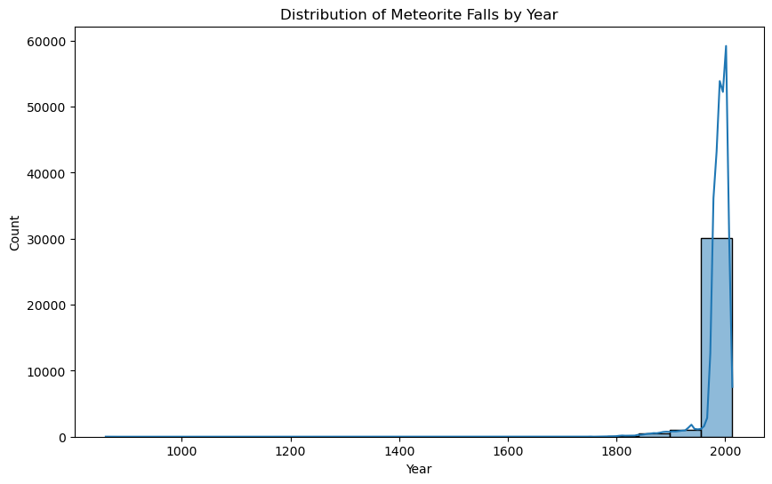

```python
plt.figure(figsize=(10, 6))
sns.histplot(df['year'], bins=20, kde=True)
plt.title('Distribution of Meteorite Falls by Year')
plt.xlabel('Year')
plt.ylabel('Count')
plt.show()
```

The histogram of meteorite falls over time reveals a dramatic shift in recorded discoveries.

For most of the dataset's history — spanning over a thousand years — the number of recorded meteorites per year remained relatively low.

This spike is likely not indicative of an actual increase in meteorite activity, but rather reflects a data reporting phenomenon. Possible explanations include:

- Advances in technology and data collection methods (e.g. satellite imagery, digital recordkeeping).
- Increased public and scientific interest in cataloging meteorites.
- The digitization and consolidation of older meteorite finds into modern databases, possibly grouped under more recent "discovery" or entry dates.

This pattern highlights the importance of distinguishing between the **fall date** of meteorites versus the **recording date**, and how modern recordkeeping has influenced the apparent volume of data in recent years.

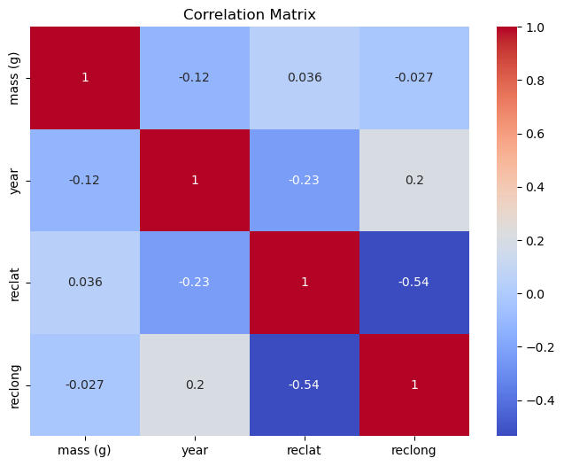

```python
correlation_matrix = df[['mass (g)', 'year', 'reclat', 'reclong']].corr()

plt.figure(figsize=(8, 6))
sns.heatmap(correlation_matrix, annot=True, cmap='coolwarm')
plt.title('Correlation Matrix')
plt.show()
```

Overall, the heatmap suggests there are no strong linear relationships between most variables.

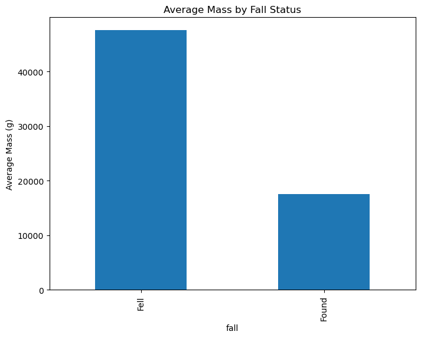

```python
# Group by fall status and get average mass
mass_by_fall = df.groupby('fall')['mass (g)'].mean()

mass_by_fall.plot(kind='bar', figsize=(8, 6))
plt.title('Average Mass by Fall Status')
plt.ylabel('Average Mass (g)')
plt.show()
```

This visualization compares the average mass of meteorites based on their fall status — whether the meteorite was "Fell" (observed as it fell) or "Found" (discovered later).

- 💥 Meteorites that were observed falling ("Fell") have a significantly **higher average mass** of around 50,000 grams.
- 🔍 Meteorites that were "Found" without a witnessed fall have a **lower average mass**, at approximately 20,000 grams.

This difference may suggest that larger meteorites are more likely to be noticed as they fall, due to their visibility, noise, or resulting impact. In contrast, smaller meteorites might go unnoticed during descent and are only discovered later, often by chance or through targeted searches.

The pattern highlights how observation bias plays a role in meteorite data — size influences detectability, and this impacts how meteorites are classified and recorded.

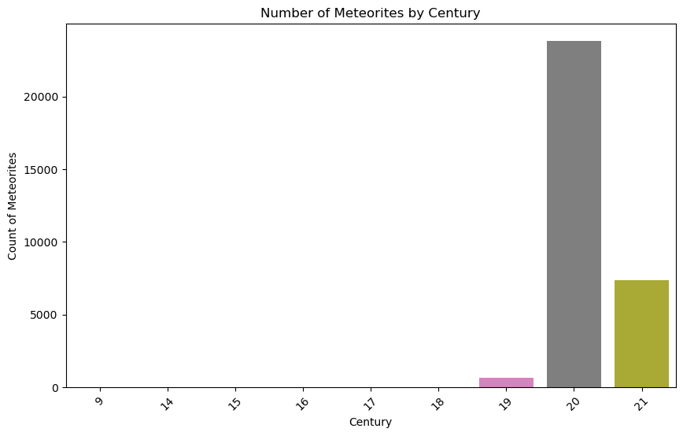

```python
# Count meteorites per century
century_count = df['century'].value_counts().sort_index()

plt.figure(figsize=(10, 6))
sns.barplot(x=century_count.index, y=century_count.values)
plt.title('Number of Meteorites by Century')
plt.xlabel('Century')
plt.ylabel('Count of Meteorites')
plt.xticks(rotation=45)
plt.show()
```

The bar chart showing the count of meteorites by century highlights a striking increase in recorded meteorite discoveries over time:

- The 20th century (1901–2000) shows the highest number of discoveries, with over 20,000 recorded meteorites.
- The 21st century (2001–2013 in this dataset) follows, with approximately 7,500 meteorites — still a very high count considering the shorter time frame.
- The 19th century (1801–1900) shows a dramatic drop-off.
- Earlier centuries have either very few or no recorded meteorites — likely due to the lack of formal tracking, scientific recording methods, or public awareness during those periods.

This trend likely reflects the rise of modern science and recordkeeping, improvements in detection technologies, and global coordination in reporting meteorite finds. It’s a strong indicator that discovery count is more about data availability and human activity than actual meteorite fall frequency.

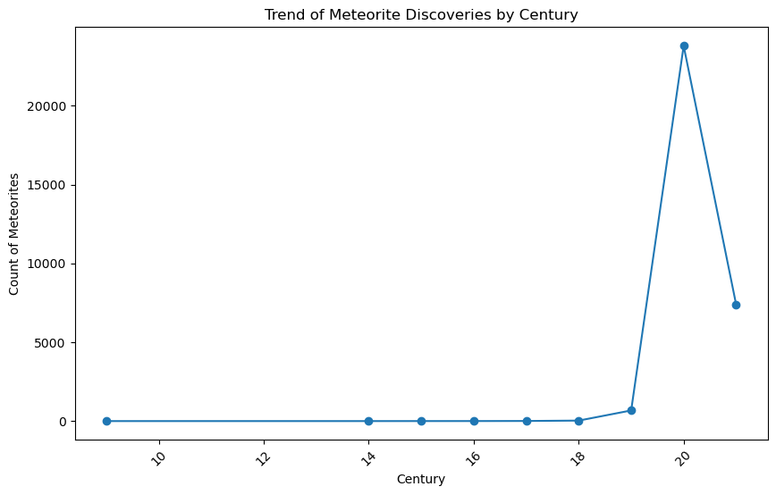

```python
# Count meteorites discovered per century
meteorite_trends_by_century = df.groupby('century').size()

plt.figure(figsize=(10, 6))
meteorite_trends_by_century.plot(kind='line', marker='o')
plt.title('Trend of Meteorite Discoveries by Century')
plt.xlabel('Century')
plt.ylabel('Count of Meteorites')
plt.xticks(rotation=45)
plt.show()
```

```python
pre_19th_centuries = df[df["century"] < 19]
```

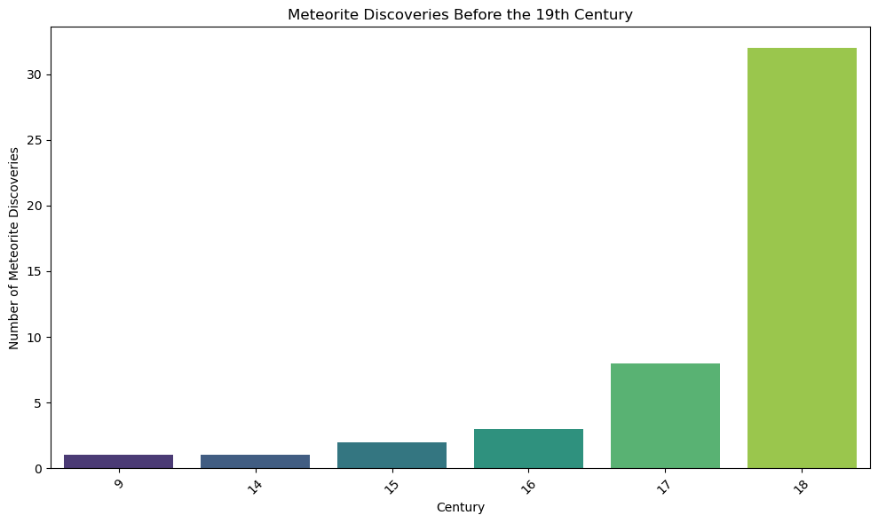

```python
century_counts = pre_19th_centuries["century"].value_counts().sort_index()

plt.figure(figsize=(10, 6))
sns.barplot(x=century_counts.index, y=century_counts.values, palette="viridis")

plt.xlabel("Century")
plt.ylabel("Number of Meteorite Discoveries")
plt.title("Meteorite Discoveries Before the 19th Century")
plt.xticks(rotation=45)
plt.tight_layout()
plt.show()
```

Meteorite discovery records before the 19th century are sparse, likely due to limited documentation and scientific awareness. Based on the data:

- Only 1 meteorite was recorded in the 9th and 14th centuries
- A small number were discovered in the 15th (2) and 16th (3) centuries
- The 17th century saw a slight rise, with 8 discoveries
- The 18th century shows the most significant uptick before the 19th, with 32 recorded meteorites

This gradual increase hints at growing scientific observation and recordkeeping leading up to the 1800s. The sharp rise in later centuries contrasts heavily with these early numbers — suggesting that improvements in technology and communication were key drivers in tracking meteorites.

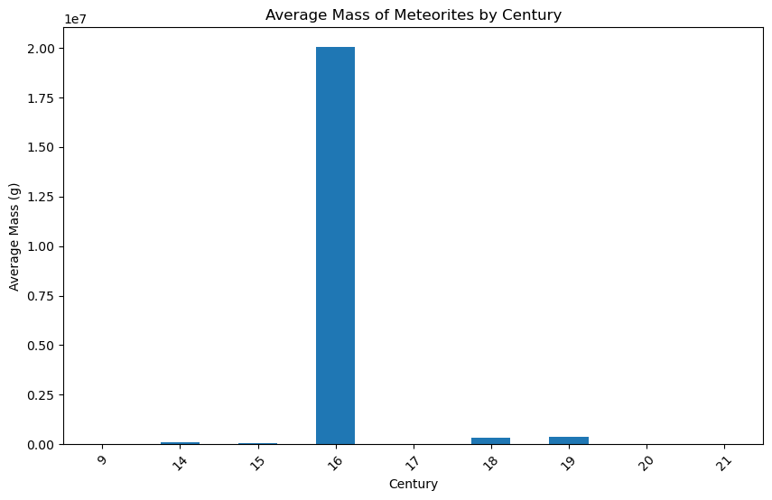

```python
# Group by century and calculate the average mass
avg_mass_by_century = df.groupby('century')['mass (g)'].mean()

plt.figure(figsize=(10, 6))
avg_mass_by_century.plot(kind='bar')
plt.title('Average Mass of Meteorites by Century')
plt.xlabel('Century')
plt.ylabel('Average Mass (g)')
plt.xticks(rotation=45)
plt.show()
```

```python
# Filter meteorites from the 16th century
century_16_data = df[df["century"] == 16]

century_16_data[["name", "mass (g)", "year"]].sort_values(by="mass (g)", ascending=False).head()
```

|  | name | mass (g) | year |
| --- | --- | --- | --- |
| 5365 | Campo del Cielo | 50000000.0 | 1575 |
| 26174 | Morito | 10100000.0 | 1600 |
| 174 | Castrovillari | 15000.0 | 1583 |

The 16th century shows an unusually high average meteorite mass due to the presence of a few exceptionally large meteorites. These outliers significantly skew the overall average mass, making it appear much larger than what would be expected based on the majority of data.

Key outliers driving this spike include:

- Campo del Cielo (1575): A meteorite with an enormous mass of 50,000,000 grams (50 metric tons).
- Morito (1600): A massive meteorite weighing 10,100,000 grams (10.1 metric tons).
- Castrovillari (1583): A much smaller, but still large meteorite at 15,000 grams (15 kg).

Interestingly, despite the Hoba meteorite weighing a massive 60 tons (a weight that's larger than Campo del Cielo), the 20th century bar for average mass is much smaller than the 16th century. This discrepancy could be due to the fact that meteorite discovery and recording became more systematic in the 20th century, leading to a much higher volume of smaller meteorites that lowers the overall average mass. On the other hand, the 16th century dataset contains fewer, but significantly larger meteorites that skew the average.

This highlights the importance of examining individual data points when interpreting summary statistics, as outliers can distort the overall trends. Without the extreme outliers, the mass distribution in the 16th century would likely resemble more typical values seen in the 19th and 20th centuries.

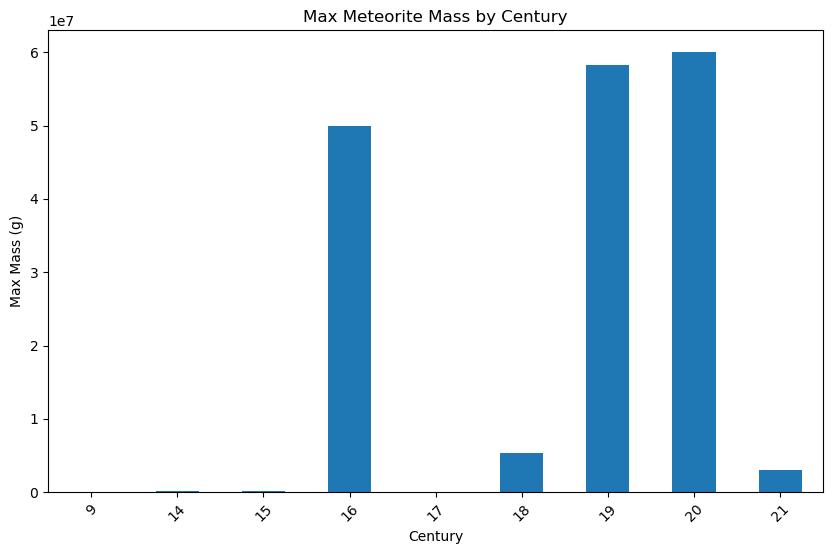

```python
# Group by century and find the max mass
max_mass_by_century = df.groupby('century')['mass (g)'].max()

plt.figure(figsize=(10, 6))
max_mass_by_century.plot(kind='bar')
plt.title('Max Meteorite Mass by Century')
plt.xlabel('Century')
plt.ylabel('Max Mass (g)')
plt.xticks(rotation=45)
plt.show()
```

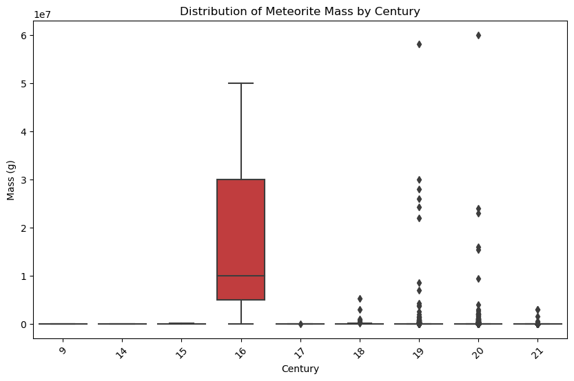

```python
# Plot boxplot of mass by century
plt.figure(figsize=(10, 6))
sns.boxplot(x='century', y='mass (g)', data=df)
plt.title('Distribution of Meteorite Mass by Century')
plt.xlabel('Century')
plt.ylabel('Mass (g)')
plt.xticks(rotation=45)
plt.show()
```

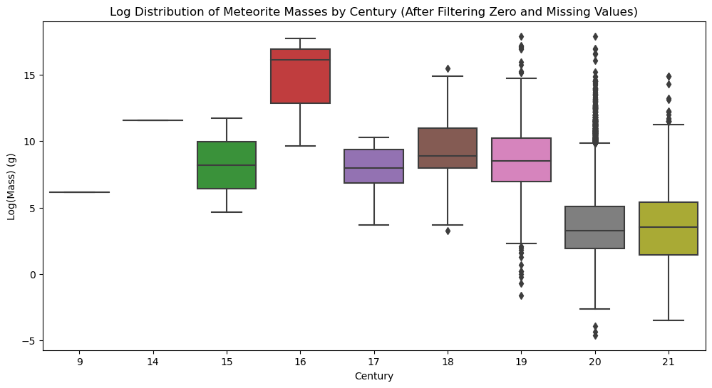

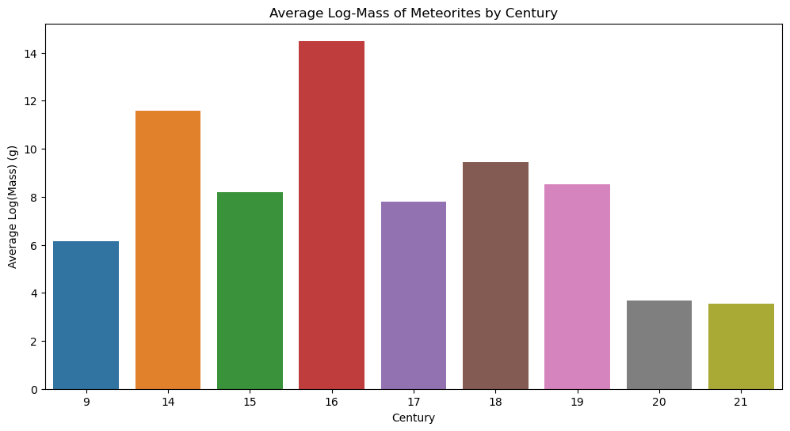

```python
# Remove zero and missing mass values
filtered_df = df[df['mass (g)'] > 0]

# Apply log transformation for better scaling of the large values
filtered_df['log_mass'] = filtered_df['mass (g)'].apply(lambda x: np.log(x) if x > 0 else 0)

plt.figure(figsize=(12, 6))

sns.boxplot(x='century', y='log_mass', data=filtered_df)
plt.title('Log Distribution of Meteorite Masses by Century (After Filtering Zero and Missing Values)')
plt.xlabel('Century')
plt.ylabel('Log(Mass) (g)')
plt.show()

fig, ax = plt.subplots(figsize=(12, 6))

century_avg_mass = filtered_df.groupby('century')['log_mass'].mean()

sns.barplot(x=century_avg_mass.index, y=century_avg_mass.values)
plt.title('Average Log-Mass of Meteorites by Century')
plt.xlabel('Century')
plt.ylabel('Average Log(Mass) (g)')
plt.show()
```

The analysis of meteorite mass distribution by century reveals interesting trends, especially when we consider the impact of extreme outliers and missing or zero values in the original data.

#### Log-Transformed Distribution of Meteorite Mass by Century:

To better understand the true distribution of meteorite masses and reduce the influence of extreme values, I applied a logarithmic transformation to the mass data. This transformation helped normalize the mass distribution and make it easier to spot patterns in the data.

After filtering out zero values and missing data, the transformed distribution shows a clearer picture:

- The 16th century still has a concentration of larger meteorites, but the impact of extreme values is now less pronounced, allowing us to see more clearly how other meteorites from the same century compare.
- The 20th century now shows a more concentrated range of meteorite masses, without being dominated by a few extreme values.
- The outliers are more easily identifiable, making it clear that certain centuries (like the 16th) have a high concentration of massive meteorites, but they do not dominate the entire dataset.

This transformation provides a better view of the underlying trends and allows us to focus on general trends in meteorite mass, without the distortion caused by extreme outliers and missing values.

### Data Regarding Composition

```python
classification_counts = df['recclass'].value_counts()

print(classification_counts)
```

```
recclass
L6                6523
H5                5586
H4                3324
H6                3231
L5                2723
                  ...
EL4/5                1
H3.5-4               1
H4(?)                1
L/LL(?)3             1
Mesosiderite-C       1
Name: count, Length: 390, dtype: int64
```

```python
df['recclass'].nunique()
```

```
390
```

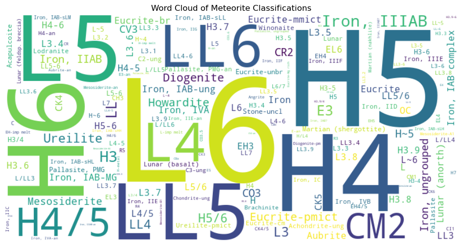

```python
from wordcloud import WordCloud

classification_counts = df['recclass'].value_counts()
wordcloud = WordCloud(width=800, height=400, background_color="white").generate_from_frequencies(classification_counts)

plt.figure(figsize=(12, 6))
plt.imshow(wordcloud, interpolation="bilinear")
plt.title('Word Cloud of Meteorite Classifications')
plt.axis('off')
plt.show()
```

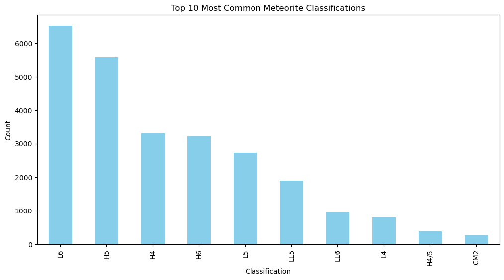

```python
# Get the top 10 most common classifications
top_10_classifications = df['recclass'].value_counts().head(10)

plt.figure(figsize=(12, 6))
top_10_classifications.plot(kind='bar', color='skyblue')
plt.title('Top 10 Most Common Meteorite Classifications')
plt.xlabel('Classification')
plt.ylabel('Count')
plt.xticks(rotation=90)
plt.show()
```

```python
classification_properties = {
    'L6': {
        'Type': 'Chondrite',
        'Composition': 'Silicate, rich in olivine and pyroxene',
        'Density (g/cm³)': '3.4',
        'Minerals': ['Olivine', 'Pyroxene', 'Plagioclase']
    },
    'H5': {
        'Type': 'Chondrite',
        'Composition': 'Silicate, contains iron-rich minerals',
        'Density (g/cm³)': '3.5',
        'Minerals': ['Olivine', 'Pyroxene', 'Magnetite']
    },
    'H4 (chondrite)': {
        'Type': 'Chondrite',
        'Composition': 'Iron-rich silicate meteorite',
        'Density (g/cm³)': '3.4',
        'Minerals': ['Olivine', 'Pyroxene', 'Magnetite']
    },
    'H6': {
        'Type': 'Chondrite',
        'Composition': 'Silicate, rich in pyroxene and olivine',
        'Density (g/cm³)': '3.6',
        'Minerals': ['Olivine', 'Pyroxene', 'Magnetite']
    },
    'L5': {
        'Type': 'Chondrite',
        'Composition': 'Silicate, primarily olivine and pyroxene',
        'Density (g/cm³)': '3.3',
        'Minerals': ['Olivine', 'Pyroxene', 'Plagioclase']
    },
    'LL5': {
        'Type': 'Chondrite',
        'Composition': 'Low-iron, silicate-rich',
        'Density (g/cm³)': '3.2',
        'Minerals': ['Olivine', 'Pyroxene', 'Plagioclase']
    },
    'LL6': {
        'Type': 'Chondrite',
        'Composition': 'Low-iron silicate meteorite',
        'Density (g/cm³)': '3.1',
        'Minerals': ['Olivine', 'Pyroxene', 'Plagioclase']
    },
    'L4': {
        'Type': 'Chondrite',
        'Composition': 'Silicate, containing olivine and pyroxene',
        'Density (g/cm³)': '3.4',
        'Minerals': ['Olivine', 'Pyroxene', 'Plagioclase']
    },
    'H4/5': {
        'Type': 'Chondrite',
        'Composition': 'Hybrid between H4 and H5 meteorites',
        'Density (g/cm³)': '3.4',
        'Minerals': ['Olivine', 'Pyroxene', 'Magnetite']
    },
    'CM2': {
        'Type': 'Carbonaceous Chondrite',
        'Composition': 'Rich in organic compounds, water, and silicate minerals',
        'Density (g/cm³)': '3.0',
        'Minerals': ['Olivine', 'Pyroxene', 'Plagioclase', 'Organic compounds']
    }
}
```

```python
# Create a DataFrame to display the classification properties
common_meteorite_df = {
    'Classification': ['L6', 'H5', 'H4', 'H6', 'L5', 'LL5', 'LL6', 'L4', 'H4/5', 'CM2'],
    'Type': ['Chondrite', 'Chondrite', 'Chondrite', 'Chondrite', 'Chondrite', 'Chondrite', 'Chondrite', 'Chondrite', 'Chondrite', 'Carbonaceous Chondrite'],
    'Composition': ['Silicate, rich in olivine and pyroxene',
                    'Silicate, contains iron-rich minerals',
                    'Iron-rich silicate meteorite',
                    'Silicate, rich in pyroxene and olivine',
                    'Silicate, primarily olivine and pyroxene',
                    'Low-iron, silicate-rich',
                    'Low-iron silicate meteorite',
                    'Silicate, containing olivine and pyroxene',
                    'Hybrid between H4 and H5 meteorites',
                    'Rich in organic compounds, water, and silicate minerals'],
    'Density (g/cm³)': ['3.4', '3.5', '3.4', '3.6', '3.3', '3.2', '3.1', '3.4', '3.4', '3.0'],
    'Minerals': ['Olivine, Pyroxene, Plagioclase',
                 'Olivine, Pyroxene, Magnetite',
                 'Olivine, Pyroxene, Magnetite',
                 'Olivine, Pyroxene, Magnetite',
                 'Olivine, Pyroxene, Plagioclase',
                 'Olivine, Pyroxene, Plagioclase',
                 'Olivine, Pyroxene, Plagioclase',
                 'Olivine, Pyroxene, Plagioclase',
                 'Olivine, Pyroxene, Magnetite',
                 'Olivine, Pyroxene, Plagioclase, Organic compounds']
}

common_meteorite_df = pd.DataFrame(common_meteorite_df)

common_meteorite_df
```

|  | Classification | Type | Composition | Density (g/cm³) | Minerals |
| --- | --- | --- | --- | --- | --- |
| 0 | L6 | Chondrite | Silicate, rich in olivine and pyroxene | 3.4 | Olivine, Pyroxene, Plagioclase |
| 1 | H5 | Chondrite | Silicate, contains iron-rich minerals | 3.5 | Olivine, Pyroxene, Magnetite |
| 2 | H4 | Chondrite | Iron-rich silicate meteorite | 3.4 | Olivine, Pyroxene, Magnetite |
| 3 | H6 | Chondrite | Silicate, rich in pyroxene and olivine | 3.6 | Olivine, Pyroxene, Magnetite |
| 4 | L5 | Chondrite | Silicate, primarily olivine and pyroxene | 3.3 | Olivine, Pyroxene, Plagioclase |
| 5 | LL5 | Chondrite | Low-iron, silicate-rich | 3.2 | Olivine, Pyroxene, Plagioclase |
| 6 | LL6 | Chondrite | Low-iron silicate meteorite | 3.1 | Olivine, Pyroxene, Plagioclase |
| 7 | L4 | Chondrite | Silicate, containing olivine and pyroxene | 3.4 | Olivine, Pyroxene, Plagioclase |
| 8 | H4/5 | Chondrite | Hybrid between H4 and H5 meteorites | 3.4 | Olivine, Pyroxene, Magnetite |
| 9 | CM2 | Carbonaceous Chondrite | Rich in organic compounds, water, and silicate... | 3.0 | Olivine, Pyroxene, Plagioclase, Organic compounds |

```python
sorted_classifications = classification_counts.sort_values(ascending=True)

# Get the top 10 least common classifications
top_10_least_common = sorted_classifications.head(10)

print(top_10_least_common)
```

```
recclass
Mesosiderite-C           1
H/L3.9                   1
EH                       1
H(?)4                    1
Martian (chassignite)    1
LL3.1-3.5                1
L(LL)6                   1
L(LL)5                   1
L/LL5-6                  1
CR-an                    1
Name: count, dtype: int64
```

```python
meteorite_properties = {
    "Mesosiderite-C": {
        "Type": "Stony-Iron",
        "Subtype": "Mesosiderite",
        "Description": "Brecciated stony-iron meteorite with a mixture of silicates and metallic iron-nickel."
    },
    "H/L3.9": {
        "Type": "Stony",
        "Subtype": "Ordinary Chondrite",
        "Description": "Transitional chondrite with properties between H and L groups, petrologic type 3.9 indicating moderate thermal metamorphism."
    },
    "EH": {
        "Type": "Stony",
        "Subtype": "Enstatite Chondrite",
        "Description": "High-iron enstatite chondrite, highly reduced minerals, formed under very low oxygen conditions."
    },
    "H(?)4": {
        "Type": "Stony",
        "Subtype": "Ordinary Chondrite (uncertain)",
        "Description": "Tentative classification, possibly an H-type chondrite with petrologic type 4."
    },
    "Martian (chassignite)": {
        "Type": "Stony",
        "Subtype": "Martian Meteorite",
        "Description": "Rare Martian meteorite, rich in olivine, from Mars' mantle. Very rare and scientifically valuable."
    },
    "LL3.1-3.5": {
        "Type": "Stony",
        "Subtype": "Ordinary Chondrite",
        "Description": "Low-iron, low-metal meteorite with petrologic types between 3.1 and 3.5, indicating low to moderate thermal alteration."
    },
    "L(LL)6": {
        "Type": "Stony",
        "Subtype": "Ordinary Chondrite (transitional)",
        "Description": "Transitional classification between L and LL chondrites, type 6 indicates high metamorphism."
    },
    "L(LL)5": {
        "Type": "Stony",
        "Subtype": "Ordinary Chondrite (transitional)",
        "Description": "Transitional between L and LL groups, petrologic type 5 indicates moderate to high thermal metamorphism."
    },
    "L/LL5-6": {
        "Type": "Stony",
        "Subtype": "Ordinary Chondrite (transitional)",
        "Description": "Falls between L and LL types, showing characteristics of both, with thermal metamorphism between types 5 and 6."
    },
    "CR-an": {
        "Type": "Stony",
        "Subtype": "Carbonaceous Chondrite (anomalous)",
        "Description": "Anomalous CR group carbonaceous chondrite with unusual composition and texture."
    }
}
```

```python
uncommon_meteorite_df = pd.DataFrame.from_dict(meteorite_properties, orient='index').reset_index()
uncommon_meteorite_df.columns = ['Classification', 'Type', 'Subtype', 'Description']

uncommon_meteorite_df
```

|  | Classification | Type | Subtype | Description |
| --- | --- | --- | --- | --- |
| 0 | Mesosiderite-C | Stony-Iron | Mesosiderite | Brecciated stony-iron meteorite with a mixture... |
| 1 | H/L3.9 | Stony | Ordinary Chondrite | Transitional chondrite with properties between... |
| 2 | EH | Stony | Enstatite Chondrite | High-iron enstatite chondrite, highly reduced ... |
| 3 | H(?)4 | Stony | Ordinary Chondrite (uncertain) | Tentative classification, possibly an H-type c... |
| 4 | Martian (chassignite) | Stony | Martian Meteorite | Rare Martian meteorite, rich in olivine, from ... |
| 5 | LL3.1-3.5 | Stony | Ordinary Chondrite | Low-iron, low-metal meteorite with petrologic ... |
| 6 | L(LL)6 | Stony | Ordinary Chondrite (transitional) | Transitional classification between L and LL c... |
| 7 | L(LL)5 | Stony | Ordinary Chondrite (transitional) | Transitional between L and LL groups, petrolog... |
| 8 | L/LL5-6 | Stony | Ordinary Chondrite (transitional) | Falls between L and LL types, showing characte... |
| 9 | CR-an | Stony | Carbonaceous Chondrite (anomalous) | Anomalous CR group carbonaceous chondrite with... |

```python
avg_mass_by_class = df.groupby('recclass')['mass (g)'].mean().reset_index()
avg_mass_by_class.columns = ['Classification', 'avg_mass']
```

```python
common_meteorite_df = common_meteorite_df.merge(avg_mass_by_class, on='Classification', how='left')
uncommon_meteorite_df = uncommon_meteorite_df.merge(avg_mass_by_class, on='Classification', how='left')
```

```python
common_meteorite_df
```

|  | Classification | Type | Composition | Density (g/cm³) | Minerals | avg_mass |
| --- | --- | --- | --- | --- | --- | --- |
| 0 | L6 | Chondrite | Silicate, rich in olivine and pyroxene | 3.4 | Olivine, Pyroxene, Plagioclase | 1708.343748 |
| 1 | H5 | Chondrite | Silicate, contains iron-rich minerals | 3.5 | Olivine, Pyroxene, Magnetite | 2563.558685 |
| 2 | H4 | Chondrite | Iron-rich silicate meteorite | 3.4 | Olivine, Pyroxene, Magnetite | 1098.059641 |
| 3 | H6 | Chondrite | Silicate, rich in pyroxene and olivine | 3.6 | Olivine, Pyroxene, Magnetite | 1112.690628 |
| 4 | L5 | Chondrite | Silicate, primarily olivine and pyroxene | 3.3 | Olivine, Pyroxene, Plagioclase | 2832.225691 |
| 5 | LL5 | Chondrite | Low-iron, silicate-rich | 3.2 | Olivine, Pyroxene, Plagioclase | 504.137045 |
| 6 | LL6 | Chondrite | Low-iron silicate meteorite | 3.1 | Olivine, Pyroxene, Plagioclase | 1247.387487 |
| 7 | L4 | Chondrite | Silicate, containing olivine and pyroxene | 3.4 | Olivine, Pyroxene, Plagioclase | 2130.273444 |
| 8 | H4/5 | Chondrite | Hybrid between H4 and H5 meteorites | 3.4 | Olivine, Pyroxene, Magnetite | 1758.714434 |
| 9 | CM2 | Carbonaceous Chondrite | Rich in organic compounds, water, and silicate... | 3.0 | Olivine, Pyroxene, Plagioclase, Organic compounds | 536.110143 |

```python
uncommon_meteorite_df
```

|  | Classification | Type | Subtype | Description | avg_mass |
| --- | --- | --- | --- | --- | --- |
| 0 | Mesosiderite-C | Stony-Iron | Mesosiderite | Brecciated stony-iron meteorite with a mixture... | 218000.00 |
| 1 | H/L3.9 | Stony | Ordinary Chondrite | Transitional chondrite with properties between... | 7250.00 |
| 2 | EH | Stony | Enstatite Chondrite | High-iron enstatite chondrite, highly reduced ... | 0.59 |
| 3 | H(?)4 | Stony | Ordinary Chondrite (uncertain) | Tentative classification, possibly an H-type c... | 16.16 |
| 4 | Martian (chassignite) | Stony | Martian Meteorite | Rare Martian meteorite, rich in olivine, from ... | 4000.00 |
| 5 | LL3.1-3.5 | Stony | Ordinary Chondrite | Low-iron, low-metal meteorite with petrologic ... | 80.10 |
| 6 | L(LL)6 | Stony | Ordinary Chondrite (transitional) | Transitional classification between L and LL c... | 265.00 |
| 7 | L(LL)5 | Stony | Ordinary Chondrite (transitional) | Transitional between L and LL groups, petrolog... | 1056.00 |
| 8 | L/LL5-6 | Stony | Ordinary Chondrite (transitional) | Falls between L and LL types, showing characte... | 3287.00 |
| 9 | CR-an | Stony | Carbonaceous Chondrite (anomalous) | Anomalous CR group carbonaceous chondrite with... | 114000.00 |

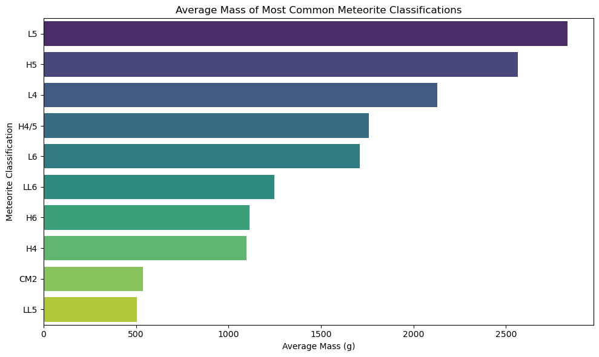

```python
plt.figure(figsize=(10, 6))
sns.barplot(
    data=common_meteorite_df.sort_values("avg_mass", ascending=False),
    x="avg_mass", y="Classification", palette="viridis"
)
plt.title("Average Mass of Most Common Meteorite Classifications")
plt.xlabel("Average Mass (g)")
plt.ylabel("Meteorite Classification")
plt.tight_layout()
plt.show()
```

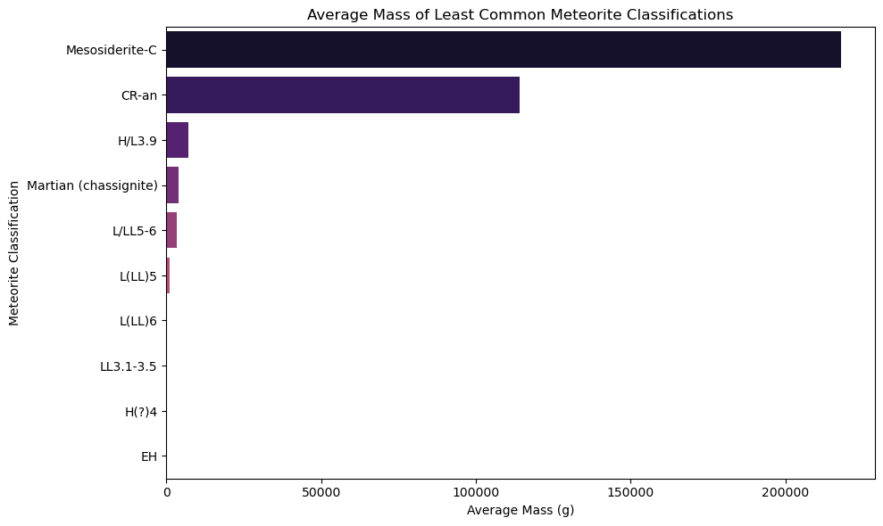

```python
plt.figure(figsize=(10, 6))
sns.barplot(
    data=uncommon_meteorite_df.sort_values("avg_mass", ascending=False),
    x="avg_mass", y="Classification", palette="magma"
)
plt.title("Average Mass of Least Common Meteorite Classifications")
plt.xlabel("Average Mass (g)")
plt.ylabel("Meteorite Classification")
plt.tight_layout()
plt.show()
```

**Mesosiderite-C** and **CR-an** stand out with significantly higher average masses (200,000g and 100,000g respectively).

The rest of the rare classifications have much lower or negligible average masses, suggesting these types may represent smaller fragments, micrometeorites, or are simply underrepresented in the dataset.

This could hint at differences in:

- Composition (e.g., metal-rich meteorites like mesosiderites tend to be heavier)
- Discovery likelihood (heavier meteorites are easier to find and more likely to be preserved)
- Atmospheric survivability (some compositions may burn up more easily)

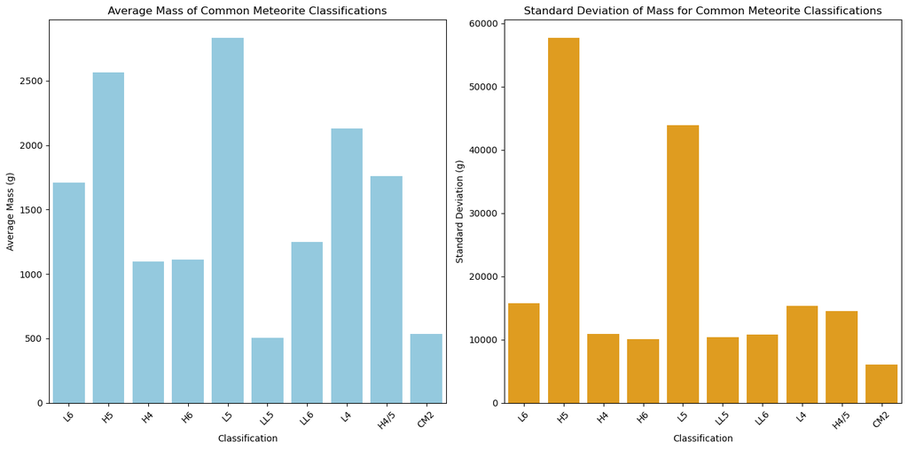

[figure not shown]

```python
# Calculate average mass and standard deviation for common meteorites
common_meteorite_stats = common_meteorite_df.copy()
common_meteorite_stats['avg_mass'] = common_meteorite_stats['Classification'].map(lambda x: df[df['recclass'] == x]['mass (g)'].mean())
common_meteorite_stats['std_mass'] = common_meteorite_stats['Classification'].map(lambda x: df[df['recclass'] == x]['mass (g)'].std())

# Calculate average mass and standard deviation for uncommon meteorites
uncommon_meteorite_stats = uncommon_meteorite_df.copy()
uncommon_meteorite_stats['avg_mass'] = uncommon_meteorite_stats['Classification'].map(lambda x: df[df['recclass'] == x]['mass (g)'].mean())
uncommon_meteorite_stats['std_mass'] = uncommon_meteorite_stats['Classification'].map(lambda x: df[df['recclass'] == x]['mass (g)'].std())

fig, (ax1, ax2) = plt.subplots(1, 2, figsize=(14, 7))

# Plot average mass for common meteorites
sns.barplot(data=common_meteorite_stats, x='Classification', y='avg_mass', ax=ax1, color='skyblue')
ax1.set_title('Average Mass of Common Meteorite Classifications')
ax1.set_ylabel('Average Mass (g)')
ax1.set_xticklabels(ax1.get_xticklabels(), rotation=45)

# Plot standard deviation for common meteorites
sns.barplot(data=common_meteorite_stats, x='Classification', y='std_mass', ax=ax2, color='orange')
ax2.set_title('Standard Deviation of Mass for Common Meteorite Classifications')
ax2.set_ylabel('Standard Deviation (g)')
ax2.set_xticklabels(ax2.get_xticklabels(), rotation=45)

plt.tight_layout()
plt.show()

fig, (ax3, ax4) = plt.subplots(1, 2, figsize=(14, 7))

# Plot average mass for uncommon meteorites
sns.barplot(data=uncommon_meteorite_stats, x='Classification', y='avg_mass', ax=ax3, color='lightgreen')
ax3.set_title('Average Mass of Uncommon Meteorite Classifications')
ax3.set_ylabel('Average Mass (g)')
ax3.set_xticklabels(ax3.get_xticklabels(), rotation=45)

# Plot standard deviation for uncommon meteorites
sns.barplot(data=uncommon_meteorite_stats, x='Classification', y='std_mass', ax=ax4, color='red')
ax4.set_title('Standard Deviation of Mass for Uncommon Meteorite Classifications')
ax4.set_ylabel('Standard Deviation (g)')
ax4.set_xticklabels(ax4.get_xticklabels(), rotation=45)

plt.tight_layout()
plt.show()
```

```python
# Calculate standard deviation of mass for each classification
common_stdev = df[df["recclass"].isin(common_meteorite_df["Classification"])] \
    .groupby("recclass")["mass (g)"].std().reset_index(name="mass_std")

uncommon_stdev = df[df["recclass"].isin(uncommon_meteorite_df["Classification"])] \
    .groupby("recclass")["mass (g)"].std().reset_index(name="mass_std")

# Merge std dev into existing dataframes
common_meteorite_df = common_meteorite_df.merge(common_stdev, left_on="Classification", right_on="recclass", how="left").drop(columns=["recclass"])
uncommon_meteorite_df = uncommon_meteorite_df.merge(uncommon_stdev, left_on="Classification", right_on="recclass", how="left").drop(columns=["recclass"])
```

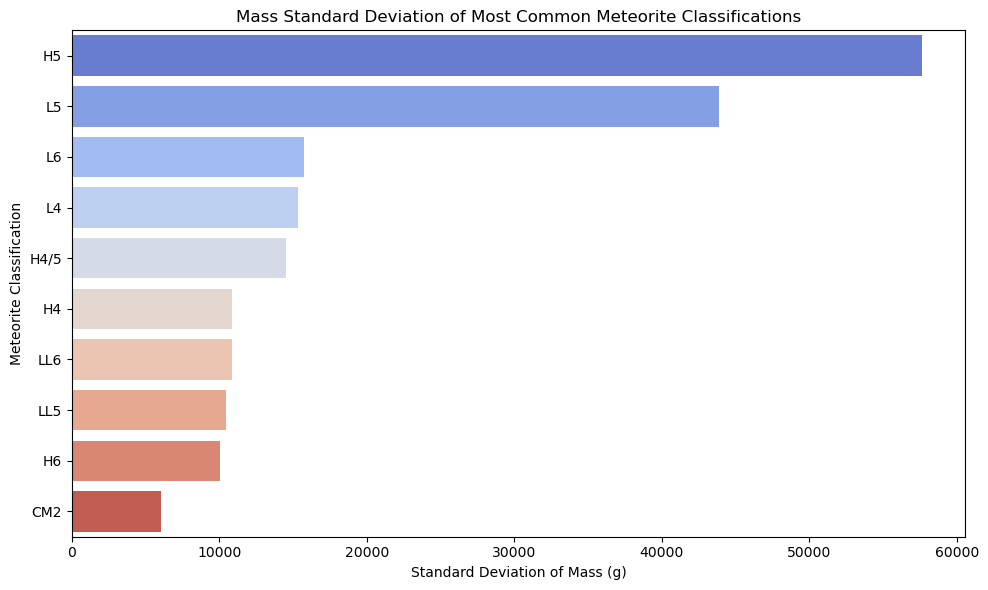

```python
plt.figure(figsize=(10, 6))
sns.barplot(
    data=common_meteorite_df.sort_values("mass_std", ascending=False),
    x="mass_std", y="Classification", palette="coolwarm"
)
plt.title("Mass Standard Deviation of Most Common Meteorite Classifications")
plt.xlabel("Standard Deviation of Mass (g)")
plt.ylabel("Meteorite Classification")
plt.tight_layout()
plt.show()
```

These findings suggest that while some classifications like H5 and L5 span a broad spectrum of sizes, others have more tightly grouped masses. This could be related to differences in composition, frequency of recovery, or fragmentation during atmospheric entry.

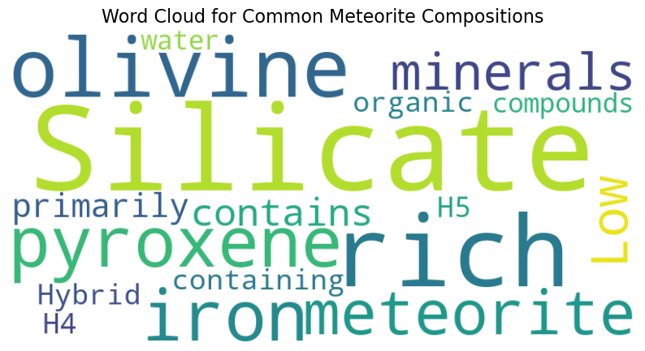

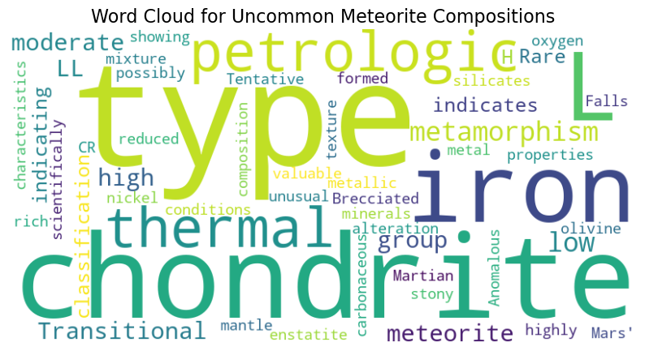

```python
def generate_wordcloud(text_data, title):
    wordcloud = WordCloud(
        width=800, height=400,
        background_color='white',
        stopwords=None,
        collocations=False
    ).generate(text_data)

    plt.figure(figsize=(10, 6))
    plt.imshow(wordcloud, interpolation='bilinear')
    plt.axis('off')
    plt.title(title, fontsize=16)
    plt.show()

common_composition_text = ' '.join(common_meteorite_df['Composition'].dropna())

uncommon_composition_text = ' '.join(uncommon_meteorite_df['Description'].dropna())

generate_wordcloud(common_composition_text, "Word Cloud for Common Meteorite Compositions")
generate_wordcloud(uncommon_composition_text, "Word Cloud for Uncommon Meteorite Compositions")
```

### Summary of Meteorite Data Analysis

1. Distribution of Meteorite Falls:

The distribution of meteorite falls by year revealed a significant spike around 2000, with a sharp increase in the number of meteorites recorded around 2000–2010. Before this period, the number of falls was significantly lower, indicating either fewer meteorites were recorded or discovered.

Century buckets revealed the concentration of meteorite falls in the 20th and 21st centuries, with very few falls from prior centuries, reinforcing the trend of modern meteorite discovery.

1. Average Mass and Outliers:

The average mass of meteorites varied significantly between centuries, with the 16th century showing the largest meteorites. However, many meteorites in the 20th and 21st centuries were notably smaller, despite some outliers, such as the Hoba meteorite.

The distribution of meteorite masses indicated that while there were outliers, the majority of meteorites weighed far less than the largest recorded masses.

1. Correlation Analysis:

The correlation matrix showed weak to moderate correlations between features. Notably, there was little correlation between the reclat, reclong, and mass columns, suggesting that meteorite size may not necessarily influence where meteorites are found geographically.

1. Meteorite Classifications:

The most common classifications by meteorite type were L6, H5, and H4 (chondrites), which dominated the dataset. These types are typically composed of silicate minerals, with distinct chemical compositions.

There were at least ten least common meteorite classifications including Mesosiderite-C, H/L3.9, and Martian (chassignite), which showed far fewer records, possibly due to their rare occurrence or discovery.

#### Key Takeaways:

Meteorite discovery peaked in the 20th and 21st centuries, reflecting technological advancements and more focused meteorite searches.

Meteorites from the 16th century were often much larger than those found in modern times, with significant outliers like the Campo del Cielo meteorite influencing mass distributions.

Meteorite classification plays a key role in understanding meteorite composition and provides insights into their origins and structure. The most common classifications were silicate-based chondrites, while rarer classifications were more exotic in composition.

The analysis showed that geographic location and mass have little correlation, suggesting that meteorite size is not a primary factor in determining fall locations.

The distribution of meteorite masses and their spread across centuries indicates that meteorite falls have become more consistent in the last few centuries.

```python
df.to_csv('original_meteorite_data.csv', index=False)
uncommon_meteorite_df.to_csv('uncommon_meteorite_data.csv', index=False)
common_meteorite_df.to_csv('common_meteorite_data.csv', index=False)
```